# Bay Wheels Ride

> The system was originally launched as Bay Area Bike Share in August 2013. At launch, it became the first regional bicycle sharing system deployed on the West Coast of the United States and also the first regional system in the U.S. that services more than just a single city or adjacent cities. The original system was described as a pilot program and consisted of only 700 bicycles with 70 stations, 34 of which were in San Francisco. The program's original administrator was the Bay Area Air Quality Management District, which handed off the public management of the system to the Metropolitan Transportation Commission in 2016. The launch system was funded with $ 11.2 million of public funds from a variety of sources, including from the MTC and Air District.

### What is the structure of your dataset?

> The Dataset Contains 13 Column describing the location of the start and the end and the time of the start and the end of the ride also it contains 152446 entries for Aug 2020 rides

### What is/are the main feature(s) of interest in your dataset?

> - we can extract a feature which is the difference in time, of the ride start and end (trip duration)
> - compare trip duration with rideable_type and member_casual
> - extract the approximated distance for long-lat and explore its relationship with other variables

### What features in the dataset do you think will help support your investigation into your feature(s) of interest?

> i would like to investigate the correlation between the distance and the trip duration, also the rideable type and the trip duration relationship

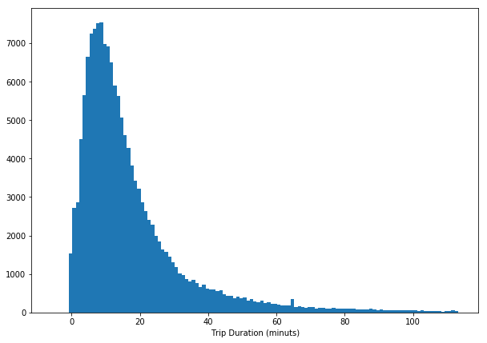

```python
plt.figure(figsize=(10,7))
bins = np.arange(min(bayWheels[bayWheels.trip_duration_hours<114].trip_duration_hours),max(bayWheels[bayWheels.trip_duration_hours<114].trip_duration_hours),1)
plt.hist(bayWheels[bayWheels.trip_duration_hours<114].trip_duration_hours,bins=bins);
plt.xlabel('Trip Duration (minuts)')
```

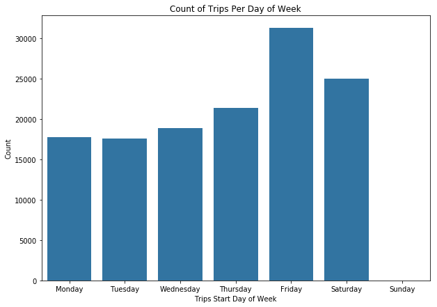

```python
plt.figure(figsize=(10,7))
sb.countplot(data=bayWheels, x='day_of_trip', color=sb.color_palette()[0],order=['Monday', 'Tuesday', 'Wednesday', 'Thursday', 'Friday', 'Saturday', 'Sunday']);
plt.xlabel('Trips Start Day of Week');
plt.ylabel('Count');
plt.title("Count of Trips Per Day of Week")
```

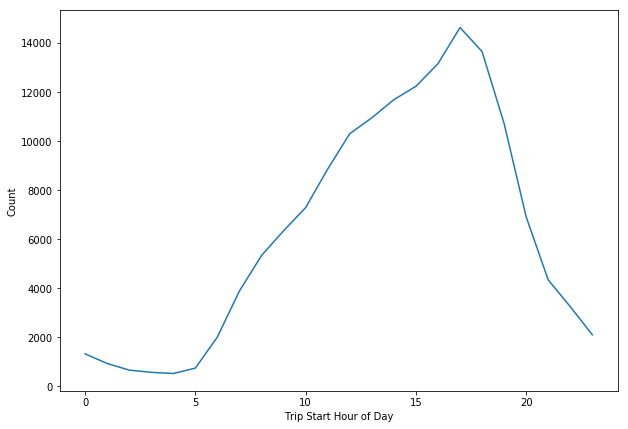

```python
plt.figure(figsize=(10,7))
sb.lineplot(x = bayWheels.hour_of_trip.value_counts().index,y=bayWheels.hour_of_trip.value_counts().values,color=sb.color_palette()[0])
plt.xlabel('Trip Start Hour of Day');
plt.ylabel('Count');
```

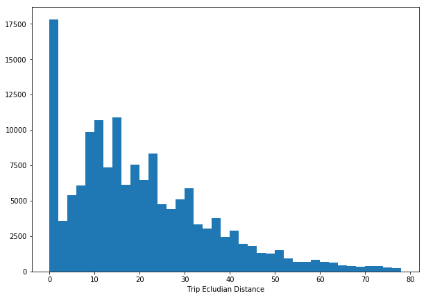

```python
plt.figure(figsize=(10,7))
bins = np.arange(min(bayWheels[bayWheels['distance']<=80]['distance']),max(bayWheels[bayWheels['distance']<=80]['distance']),2)
plt.hist(bayWheels[bayWheels['distance']<=80]['distance'],bins=bins)
plt.xlabel('Trip Ecludian Distance');
```

### Discuss the distribution(s) of your variable(s) of interest. Were there any unusual points? Did you need to perform any transformations?

> - both the distance and the trip duration are right skewed distributions, and they both have an outliers i guess there might be a positive corrleation between those two variables,
> - i am curious to investigate if there are relationship between the day of week and the hour of day also the trip duration and the day of week.
> - there is 9833 rides where the start station is the same as the end station ### Of the features you investigated, were there any unusual distributions? Did you perform any operations on the data to tidy, adjust, or change the form of the data? If so, why did you do this?

> the distribution of the ecludian distance was in a small scale as it depends on the long-lat data so i filtered the outliers also multiplied by 1000 to have a better visualization, the Trip Duration distribution too, i filtered the outliers there was no need to change the scale.

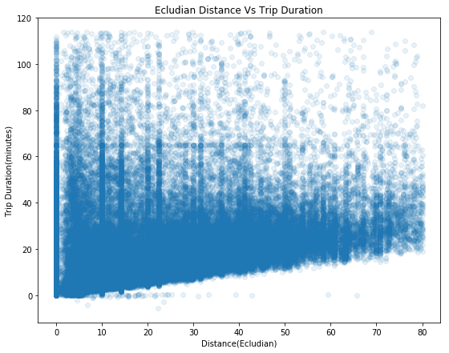

```python
plt.figure(figsize=(9,7))
filtered = bayWheels[(bayWheels.distance<=80)&(bayWheels.trip_duration_hours<=114)]
plt.scatter(filtered2[(filtered2.distance<=80)&(filtered2.trip_duration_hours<=114)]['distance'],filtered2[(filtered2.distance<=80)&(filtered2.trip_duration_hours<=114)]['trip_duration_hours'],alpha=0.1)
plt.xlabel("Distance(Ecludian)")
plt.ylabel("Trip Duration(minutes)")
plt.title("Ecludian Distance Vs Trip Duration")
```

> this is very intersting as we can see there is two things to note:
> - there is a correlation between the distance and the trip duration and this is logical
> - although there are many points with zero ecludian distance and the trip duration increases means that the start and the end long-lats are the same.

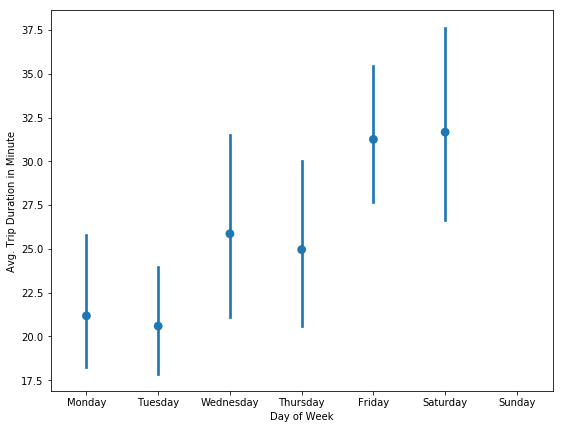

```python
plt.figure(figsize=(9,7))
sb.pointplot(x=bayWheels.day_of_trip, y=bayWheels.trip_duration_hours, dodge=0.3,join=False,order=['Monday', 'Tuesday', 'Wednesday', 'Thursday', 'Friday', 'Saturday', 'Sunday']);
plt.xlabel('Day of Week');
plt.ylabel('Avg. Trip Duration in Minute')
```

- the average trip duration is at its maximum in friday and saturday

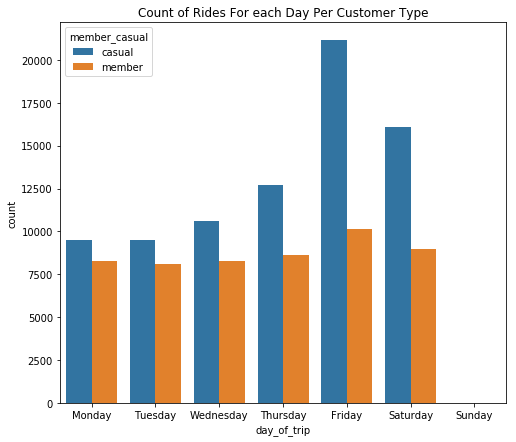

```python
plt.figure(figsize=(8,7))
sb.countplot(data=bayWheels,x='day_of_trip',hue='member_casual',order=['Monday', 'Tuesday', 'Wednesday', 'Thursday', 'Friday', 'Saturday', 'Sunday'])
plt.title("Count of Rides For each Day Per Customer Type")
```

> Most of Casual memebers participate on Friday

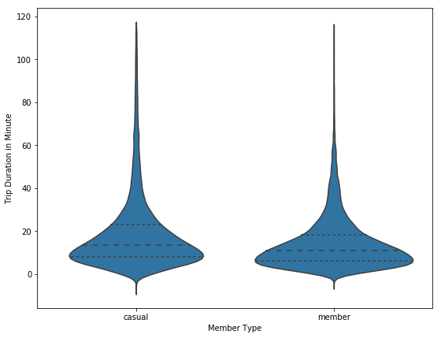

```python
plt.figure(figsize=(9,7))
sb.violinplot(data=filtered, x='member_casual', y='trip_duration_hours', color=sb.color_palette()[0], inner='quartile');
plt.xlabel('Member Type');
plt.ylabel('Trip Duration in Minute');
```

### Did you observe any interesting relationships between the other features (not the main feature(s) of interest)?

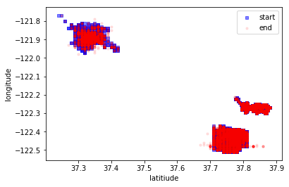

```python
fig = plt.figure()
ax1 = fig.add_subplot(111)

ax1.scatter(filtered.start_lat, filtered.start_lng, s=10, c='b', marker="s", label='start',alpha=0.5)
ax1.scatter(filtered.end_lat,filtered.end_lng, s=10, c='r', marker="o", label='end',alpha=0.1)
plt.legend();
plt.xlabel('latitiude')
plt.ylabel('longitude')
plt.show()
```

> This is an intersting graph after removing the outliers we can see a three main regions where the trips start and end

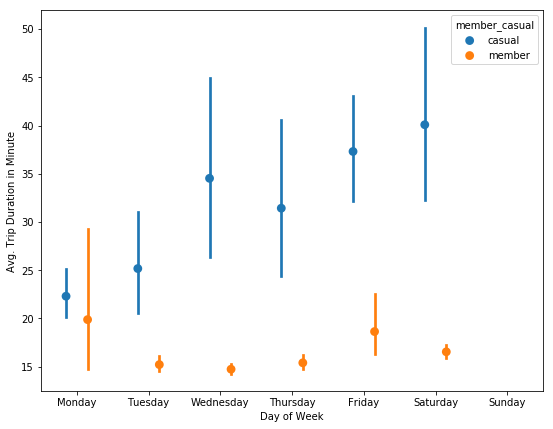

```python
plt.figure(figsize=(9,7))
sb.pointplot(x=bayWheels.day_of_trip, y=bayWheels.trip_duration_hours,hue=bayWheels.member_casual, dodge=0.3,join=False,order=['Monday', 'Tuesday', 'Wednesday', 'Thursday', 'Friday', 'Saturday', 'Sunday']);
plt.xlabel('Day of Week');
plt.ylabel('Avg. Trip Duration in Minute')
```

### Talk about some of the relationships you observed in this part of the investigation. Were there features that strengthened each other in terms of looking at your feature(s) of interest?

> - There are Three Main Region Where the rides take place
> - Members Tend to finish faster than Casual Riders In all days of Weeks
> - There is a Positive Correlation Between Distance and Trip Duration.

### Were there any interesting or surprising interactions between features?

> - There are Three Main Region Where the rides take place that was surprising as there were alot of stations but they are all clustered around three regions
> - The Ecludian distance might be zero this means that the start and the end are in the same station